# Bioestadística, Zootecnia

Clase 10: Distribuciones de probabilidad y aplicaciones

Departamento de Estadı́stica, Sede Bogotá

## Contenido

### Parte I: Distribuciones discretas

- FMP, FDA y su relación.
- Binomial: FMP, FDA y efecto de $n$, $p$.
- Poisson: FMP, FDA y efecto de $\lambda$.
- Probabilidades en R: todos los casos.

### Parte II: Distribuciones continuas

- Uniforme, Normal (tabla Z), Exponencial.
- Gamma, Beta, Chi-cuadrado, t de Student.
- FDP, FDA y efecto de los parámetros.
- Probabilidades en R y aproximaciones.

Funciones de Probabilidad y Densidad

FMP, FDP y distribuciones en profundidad

Herramientas matemáticas para cuantificar la incertidumbre

Bioestadística Fundamental, Departamento de Estadística, UNAL Bogotá

## Resumen Clase 9

**Variable aleatoria:** $X:\Omega\to\mathbb{R}$ · **Discreta:** FMP $p(x)=P(X=x)\geq 0,\ \textstyle\sum p=1$ · **Continua:** FDP $f(x)\geq 0,\ \int f=1$ · **FDA:** $F(x)=P(X\leq x)$

Distribuciones discretas

| Bernoulli($p$) | Éxito/fracaso único. $p(x)=p^x(1-p)^{1-x}$ |
| --- | --- |
| Bin($n,p$) | $k$ éxitos en $n$ ensayos. $\binom{n}{k}p^k(1-p)^{n-k}$ |
| Poi($\lambda$) | Eventos raros. $e^{-\lambda}\lambda^k/k!$ |
| Geo($p$) | Intentos hasta primer éxito. $(1-p)^{k-1}p$ |
| Hiper($N,K,n$) | Sin reemplazo. $\binom{K}{k}\binom{N-K}{n-k}/\binom{N}{n}$ |

Distribuciones continuas

| $U(a,b)$ | Densidad constante $1/(b-a)$ en $(a,b)$ |
| --- | --- |
| $N(\mu,\sigma^2)$ | Campana simétrica; $Z=(X-\mu)/\sigma$ |
| $\text{Exp}(\lambda)$ | Tiempos de espera; sin memoria |
| $\text{Gamma}(\alpha,\beta)$ | Tiempo hasta el $k$-ésimo evento |
| $\text{Beta}(\alpha,\beta)$ | Proporciones en $(0,1)$ |

## El hilo del curso: clases 1 a 10

1–3

Describir

Tablas, gráficos, tasas, medidas de posición y dispersión.

Estadística descriptiva

4–5

Relacionar

Dispersión, correlación, tablas de contingencia y análisis bivariado.

Estadística bivariada

6–8

Medir la incertidumbre

Eventos, probabilidad condicional, independencia y Bayes.

Teoría de probabilidad

9

Cuantificar

Variables aleatorias, FDA, FMP y FDP. Distribuciones discretas.

Variables aleatorias

10

Modelar

Distribuciones continuas: Uniforme, Normal, Exponencial, Gamma, Beta, $\chi^2$, $t$.

Modelos probabilísticos

Hoy tenemos todas las piezas para el siguiente paso: inferencia estadística.

## FMP y FDA

Función de Masa de Probabilidad

$$p(x) = P(X = x)$$
Asigna una probabilidad a **cada valor individual**. Responde: ¿con qué chance ocurre exactamente $x$?

Función de Distribución Acumulada

$$F(x) = P(X \leq x) = \sum_{x_i \leq x} p(x_i)$$
**Acumula** toda la probabilidad hasta $x$. Responde: ¿con qué chance ocurre $x$ o menos?

La FDA **suma** la FMP. Y la FMP indica**cuánto** aumenta la FDA en cada valor, osea, el salto que se da

Distribución Binomial

Decir que una variable sigue una Distribución Binomial significa que estamos contando cuántas veces ocurre un evento en un número fijo de unidades, donde cada unidad solo tiene dos posibles resultados.

## FMP y FDA: Distribución Binomial

FMP: $X \sim \text{Bin}(3,\, 0.4)$

$$p(x) = \binom{3}{x}(0.4)^x(0.6)^{3-x}$$

| $x$ | $p(x) = P(X=x)$ |
| --- | --- |
| 0 | $\binom{3}{0}(0.4)^0(0.6)^3 = 0.216$ |
| 1 | $\binom{3}{1}(0.4)^1(0.6)^2 = 0.432$ |
| 2 | $\binom{3}{2}(0.4)^2(0.6)^1 = 0.288$ |
| 3 | $\binom{3}{3}(0.4)^3(0.6)^0 = 0.064$ |

FDA: $F(x) = P(X \leq x)$

$$F(x) = \sum_{x_i \leq x} p(x_i)$$

| $x$ | $F(x) = P(X \leq x)$ |
| --- | --- |
| 0 | $0.216$ |
| 1 | $0.216 + 0.432 = 0.648$ |
| 2 | $0.648 + 0.288 = 0.936$ |
| 3 | $0.936 + 0.064 = 1.000$ |

$P(X \leq 1) = F(1) = 0.648$; $P(X = 2) = F(2) - F(1) = 0.936 - 0.648 = 0.288$; $P(X > 2) = 1 - F(2) = 0.064$

## Gráfica FMP y FDA: Binomial (n=3, p=0.4)

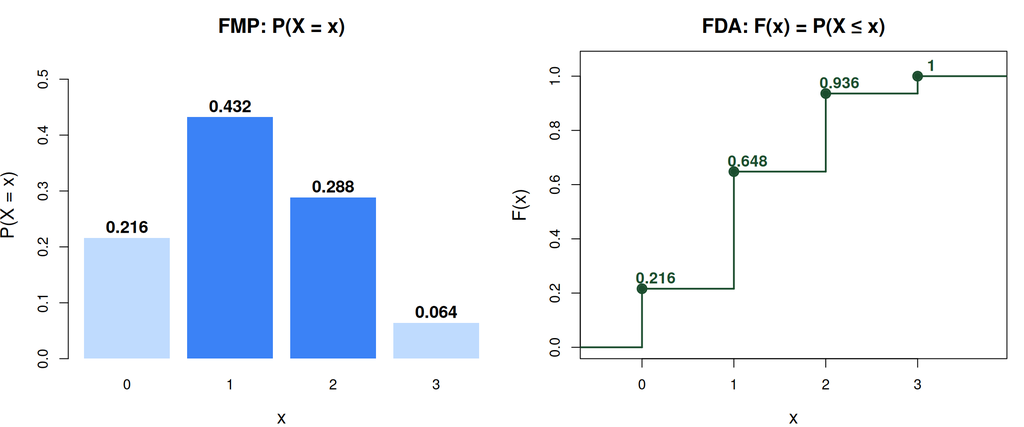

## Efecto de los parámetros en la Distribución Binomial

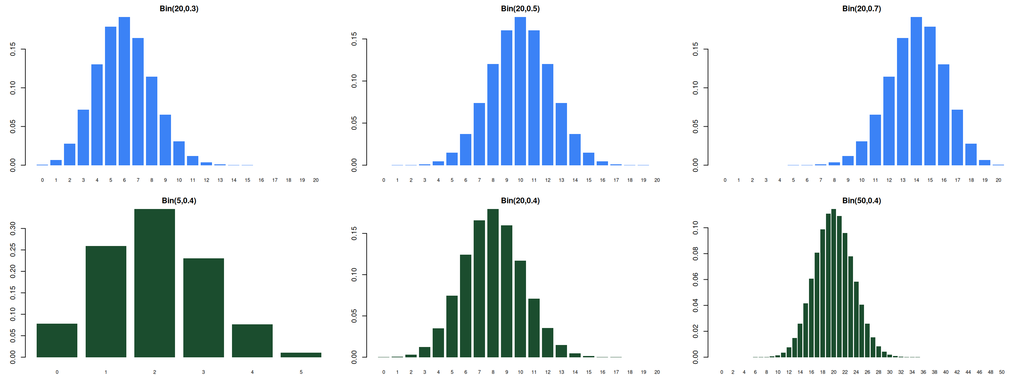

## R: Distribución Binomial

En un lote de $n=50$ animales del hato, con $p=0.15$ de tener mastitis. Calcule $P(X=8)$, $P(X \leq 10)$, $P(X > 12)$, $P(X \geq 12)$ y $P(5 \leq X \leq 12)$.

```r
n <- 50; p <- 0.15

# Exactamente 8 animales
dbinom(8, n, p)
```

```
[1] 0.1493486
```

```r
# Menor o igual que 10
pbinom(10, n, p)
```

```
[1] 0.8800827
```

```r
# Estrictamente menor que 10
pbinom(9, n, p)
```

```
[1] 0.7910937
```

```r
# Mayor que 12
pbinom(12, n, p, lower.tail = FALSE)
```

```
[1] 0.03006053
```

```r
# Mayor o igual que 12
pbinom(11, n, p,lower.tail = FALSE)
```

```
[1] 0.06281207
```

```r
# Entre 5 y 12 (inclusive)
pbinom(12, n, p) - pbinom(4, n, p)
```

```
[1] 0.8578343
```

**`dbinom(x, n, p):`** $P(X = x)$

**`pbinom(q, n, p):`** $P(X \leq q)$

**`pbinom(q-1, n, p):`** $P(X < q)$

**`lower.tail = FALSE:`** $P(X > q)$

**`pbinom(q-1,…,FALSE):`** $P(X \geq q)$

**`pbinom(b) - pbinom(a-1):`** $P(a \leq X \leq b)$

## Aplicaciones en Zootecnia: Distribución Binomial

🌿

Supervivencia de animales

De $n=20$ terneros asignadas en **Córdoba**, cada una sobrevive con probabilidad $p=0.85$. ¿Cuántas sobrevivirán?

$X \sim \text{Bin}(20,\, 0.85)$

🦠

Animales con enfermedad

En un muestreo de $n=50$ animales del hato en **Huila**, cada animal tiene probabilidad $p=0.15$ de presentar mastitis.

$X \sim \text{Bin}(50,\, 0.15)$

✂️

Éxito de esquejes en criadero

De $n=30$ esquejes de ternero injertados en criaderos de **Antioquia**, cada uno prende con probabilidad $p=0.70$.

$X \sim \text{Bin}(30,\, 0.70)$

Se usa cuando hay **$n$ ensayos independientes**, cada uno con probabilidad $p$ de éxito y dos resultados posibles.

Distribución Poisson

Decir que una variable sigue una Distribución Poisson significa que estamos contando cuántas veces ocurre un evento en un intervalo de espacio, tiempo o área, cuando los eventos aparecen de manera aleatoria.

## FMP y FDA: fórmulas de la Distribución Poisson

Función de Masa de Probabilidad

$$p(x) = P(X = x) = \frac{e^{-\lambda}\,\lambda^x}{x!}, \quad x = 0, 1, 2, \ldots$$

- $\lambda > 0$: tasa promedio de ocurrencias.
- Cada valor tiene probabilidad estrictamente positiva.
- La suma de todas las probabilidades es 1: $\displaystyle\sum_{x=0}^{\infty} p(x) = 1$.

Función de Distribución Acumulada

$$F(x) = P(X \leq x) = \sum_{k=0}^{\lfloor x \rfloor} \frac{e^{-\lambda}\,\lambda^k}{k!}$$

- Función escalonada: sube en cada entero no negativo.
- El salto en $x = k$ es exactamente $p(k)$.
- $F(x) \to 1$ cuando $x \to \infty$.

No existe fórmula cerrada para $F(x)$: se calcula sumando términos de la FMP. En R: `dpois(x, λ)` para la FMP y `ppois(x, λ)` para la FDA.

## FMP y FDA: Distribución Poisson ($\lambda = 0.3$)

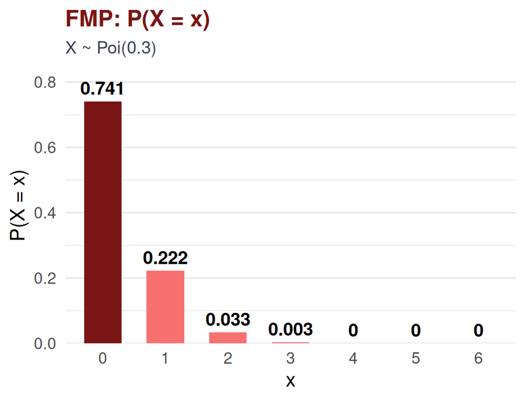

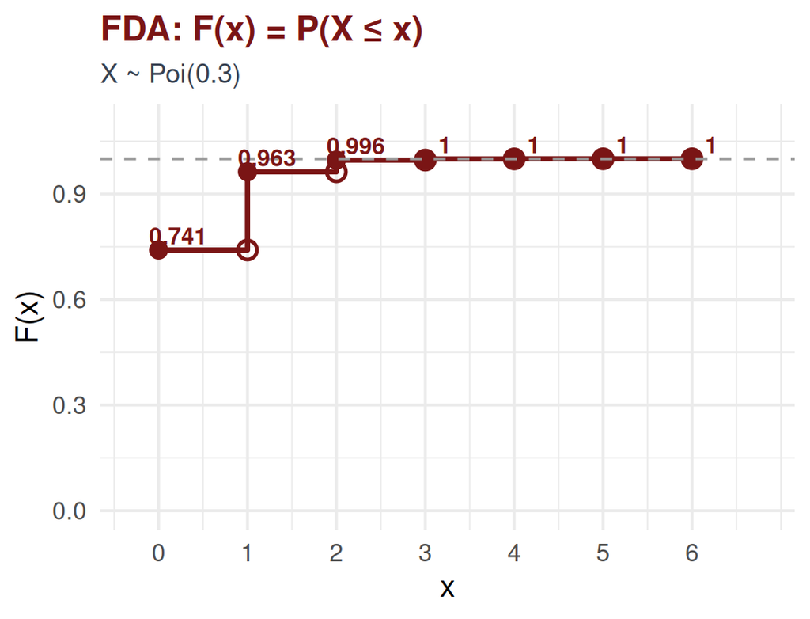

Con $\lambda = 0.3$, la masa se concentra en $x = 0$: $P(X=0) = e^{-0.3} \approx 0.741$. Modela eventos muy raros.

La FDA sube casi de golpe: $F(0) \approx 0.741$, $F(1) \approx 0.963$. El $96.3\%$ de las veces ocurre 1 o ningún evento.

## Efecto del parámetro λ en la Distribución Poisson

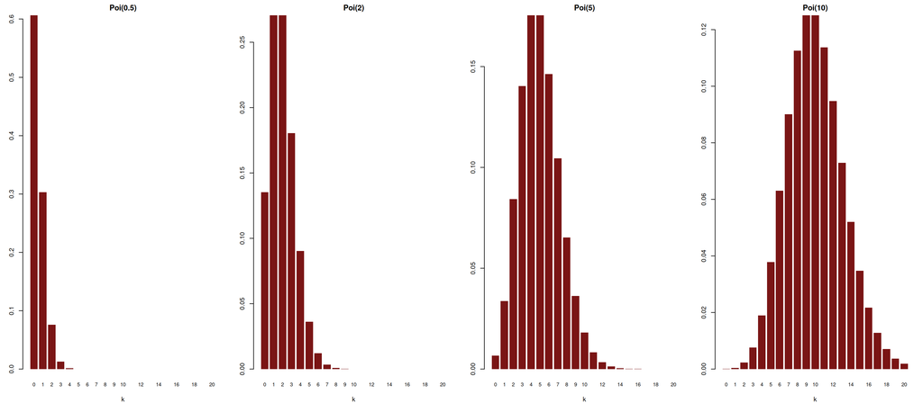

Para $\lambda$ grande, la Poisson se aproxima a una distribución Normal.

## R: Distribución Poisson

Brotes de sigatoka por semana en banano, $\lambda=4.2$. Calcule $P(X=3)$, $P(X \leq 5)$, $P(X > 6)$, $P(X \geq 7)$ y $P(3 \leq X \leq 6)$.

```r
lambda <- 4.2

# Exactamente 3 brotes
dpois(3, lambda)
```

```
[1] 0.1851654
```

```r
# Menor o igual que 5
ppois(5, lambda)
```

```
[1] 0.7531429
```

```r
# Estrictamente menor que 5
ppois(4, lambda)
```

```
[1] 0.589827
```

```r
# Mayor que 6
ppois(6, lambda, lower.tail = FALSE)
```

```
[1] 0.132536
```

```r
# Mayor o igual que 7
ppois(6, lambda, lower.tail = FALSE)
```

```
[1] 0.132536
```

```r
# Entre 3 y 6 (inclusive)
ppois(6, lambda) - ppois(2, lambda)
```

```
[1] 0.657226
```

**`dpois(x, lambda):`** $P(X = x)$

**`ppois(q, lambda):`** $P(X \leq q)$

**`ppois(q-1, lambda):`** $P(X < q)$

**`lower.tail = FALSE:`** $P(X > q)$

**`ppois(q-1,…,FALSE):`** $P(X \geq q)$

**`ppois(b) - ppois(a-1):`** $P(a \leq X \leq b)$

## Relación diferencial entre FDP y FDA

Definición

Si $X$ es v.a continua con FDP $f(x)$ y FDA $F(x)$:
$$F(x) = \int_{-\infty}^{x} f(t)\,dt$$
$$f(x) = F'(x) \quad \text{(donde existe la derivada)}$$

- La FDP es la **derivada** de la FDA: mide la densidad de probabilidad en cada punto.
- Las zonas donde $f(x)$ es alta concentran mayor probabilidad.

## Aplicaciones en Zootecnia: Distribución Poisson

🦟

Focos de enfermedad por animal

Número de brotes de sigatoka por semana en lotes de banano en **Urabá**. Eventos raros en un intervalo definido.

$X \sim \text{Poi}(\lambda)$, $\lambda$ = brotes/semana

🌧️

Eventos de granizo por temporada

Número de eventos de granizo que afectan lotes de aves en la **Sabana de Bogotá** durante la temporada lluviosa.

$X \sim \text{Poi}(\lambda)$, $\lambda$ = eventos/mes

🔬

Colonias bacterianas en muestra

Número de colonias de *E. coli* encontradas en muestras de agua de alimentación en lotes de hortalizas en **Cundinamarca**.

$X \sim \text{Poi}(\lambda)$, $\lambda$ = colonias/mL

Ideal para **contar eventos raros** en un intervalo de tiempo, espacio o área cuando los eventos son independientes.

Distribución Uniforme

Decir que una variable sigue una Distribución Uniforme significa que todos los valores dentro de un intervalo tienen la misma probabilidad de ocurrir.

## FDP y FDA de la Distribución Uniforme

Distribución Uniforme continua $X \sim U(a, b)$

Todos los valores en $(a, b)$ tienen la **misma probabilidad** de ocurrir. La densidad es constante en todo el soporte. , Parámetros: $a$ (límite inferior), $b$ (límite superior).

Función de Densidad (FDP)

$$f(x) = \frac{1}{b-a}, \quad a < x < b$$

Densidad **constante**: ningún valor es más probable que otro dentro del intervalo.

Función de Distribución Acumulada (FDA)

$$F(x) = \begin{cases} 0, & x < a \\[4pt] \dfrac{x-a}{b-a}, & a \leq x \leq b \\[8pt] 1, & x > b \end{cases}$$

## FDP y FDA: Distribución Uniforme con $a=1$ y $b=4$

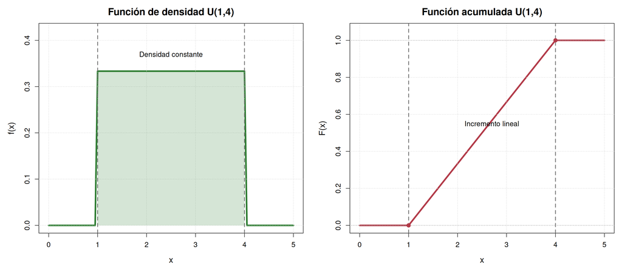

## R: Distribución Uniforme

El tiempo de maduración (días) de un animal de corderos sigue una $U(60, 90)$. Calcule $P(X=72)$, $P(X \leq 75)$, $P(X > 80)$, $P(X \geq 80)$ y $P(65 \leq X \leq 80)$.

```r
a <- 60; b <- 90

# Exactamente 72 días (continua → siempre 0)
dunif(72, a, b)
```

```
[1] 0.03333333
```

```r
# Menor o igual que 75
punif(75, a, b)
```

```
[1] 0.5
```

```r
# Estrictamente menor que 75 (igual para continua)
punif(75, a, b)
```

```
[1] 0.5
```

```r
# Mayor que 80
punif(80, a, b, lower.tail = FALSE)
```

```
[1] 0.3333333
```

```r
# Mayor o igual que 80 (igual para continua)
punif(80, a, b, lower.tail = FALSE)
```

```
[1] 0.3333333
```

```r
# Entre 65 y 80 (inclusive)
punif(80, a, b) - punif(65, a, b)
```

```
[1] 0.5
```

**`dunif(x, min, max):`** $f(x) = 1/(b-a)$

**`punif(q, min, max):`** $P(X \leq q)$

**`lower.tail = FALSE:`** $P(X > q)$

**`punif(b) - punif(a):`** $P(a \leq X \leq b)$

Nota: variable continua

$P(X = x) = 0$ siempre.  
$P(X \leq q) = P(X < q)$

## Aplicaciones en Zootecnia: Distribución Uniforme

🌻

Época de floración

El inicio de floración del ovinos en una dieta puede ocurrir en cualquier día dentro de una ventana de 15 días en **Meta**.

$X \sim U(60,\, 75)$ días

💧

Tiempo de activación de alimentación

Sistema de alimentación automático programado para activarse en un intervalo fijo en lotes de cebolla en **Pasto**.

$X \sim U(10,\, 30)$ minutos

🌱

Tiempo de supervivencia

Animales de corderos en condiciones controladas sobreviven con igual probabilidad en cualquier día entre el 5° y el 15° en **Boyacá**.

$X \sim U(5,\, 15)$ días

Se usa cuando se conocen los límites del fenómeno pero **no hay preferencia** por ningún valor dentro del rango.

Distribución Normal

Decir que una variable sigue una Distribución Normal significa que la mayoría de los valores se concentran alrededor de un promedio, y los valores extremos son menos frecuentes. Es la famosa distribución en forma de “campana”.

## FDP y FDA de la Distribución Normal

Distribución Normal $X \sim N(\mu,\, \sigma^2)$

Variable continua con forma de campana simétrica alrededor de $\mu$. Parametrizada por la **media** $\mu \in \mathbb{R}$ y la **varianza** $\sigma^2 > 0$.

Función de Densidad (FDP)

$$f(x) = \frac{1}{\sigma\sqrt{2\pi}}\, e^{-\frac{1}{2}\left(\frac{x-\mu}{\sigma}\right)^2}, \quad x \in \mathbb{R}$$

Simétrica en $\mu$ · máximo en $x = \mu$ · colas asintóticas al eje $x$.

Función de Distribución Acumulada (FDA)

$$F(x) = \Phi\!\left(\frac{x - \mu}{\sigma}\right) = \int_{-\infty}^{x} f(t)\,dt$$

No tiene forma cerrada. Se calcula estandarizando: $Z = \dfrac{X - \mu}{\sigma} \sim N(0,1)$ y usando la tabla $\Phi$.

No existe una fórmula sencilla para calcular directamente la FDA de la normal. Por eso usamos la normal estándar, tablas o un software estadístico como R para calcular.

## Gráfica FDP y FDA: Normal ($\mu = 3,\ \sigma = 7$)

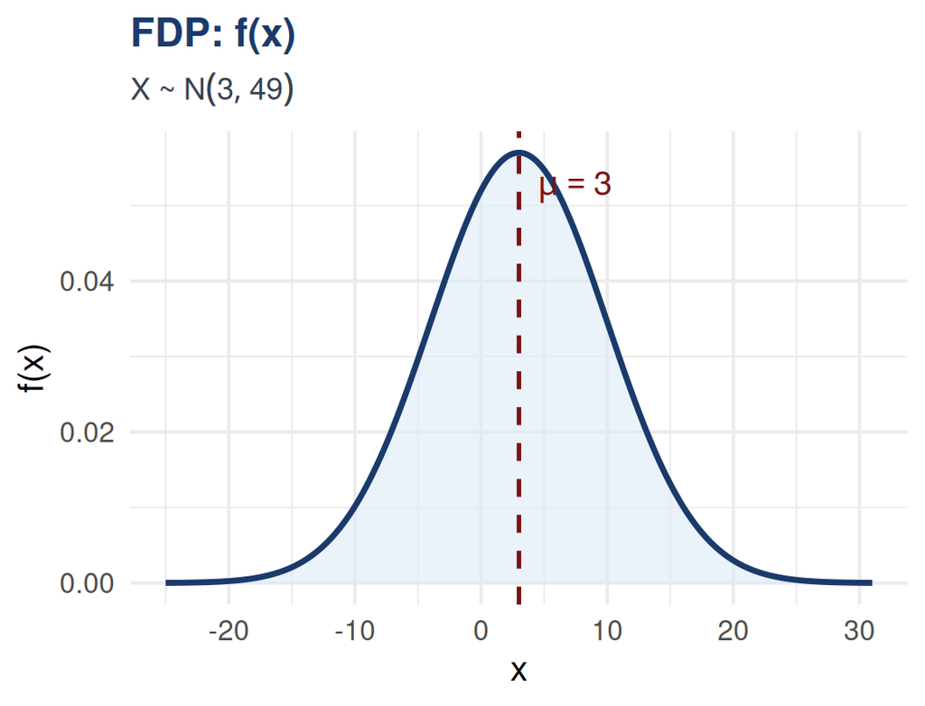

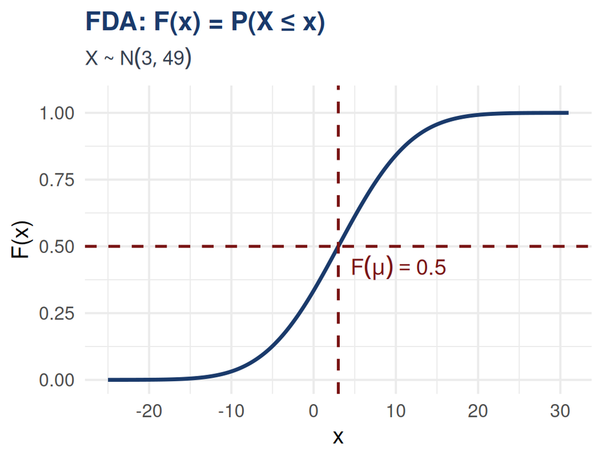

La FDP es simétrica en $\mu = 3$ · La FDA cruza $0.5$ exactamente en $x = \mu$ · $\sigma = 7$ produce una campana **ancha** con alta dispersión.

## Efecto de μ y σ en la Normal

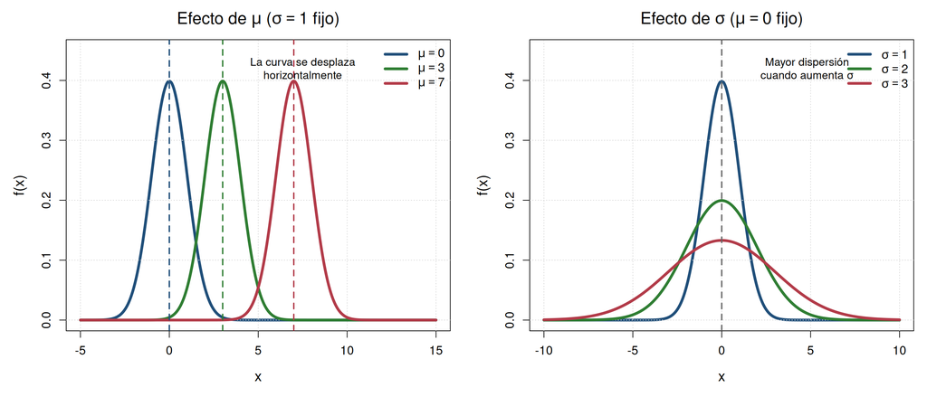

## La regla del 68%, 95% y 99.7%

Regla empírica de la Normal

Para $X \sim N(\mu, \sigma^2)$:
$$P(\mu - \sigma \leq X \leq \mu + \sigma) \approx 0.6827$$
$$P(\mu - 2\sigma \leq X \leq \mu + 2\sigma) \approx 0.9545$$
$$P(\mu - 3\sigma \leq X \leq \mu + 3\sigma) \approx 0.9973$$

```r
# Comando en R
round(diff(pnorm(c(-1,1))), 4)    # Para ±1σ El área bajo la curva es de aproximadamente 68%
```

```
[1] 0.6827
```

```r
round(diff(pnorm(c(-2,2))), 4)    # Para ±2σ El área bajo la curva es de aproximadamente 95%
```

```
[1] 0.9545
```

```r
round(diff(pnorm(c(-3,3))), 4)    # Para ±3σ El área bajo la curva es de aproximadamente 99.7%
```

```
[1] 0.9973
```

## Uso de la tabla Z (Estandarización)

Definición

Si $X \sim N(\mu, \sigma^2)$, entonces $Z = \frac{X-\mu}{\sigma} \sim N(0,1)$. Por lo tanto:
$$P(X \leq x) = P\!\left(Z \leq \frac{x-\mu}{\sigma}\right) = \Phi\!\left(\frac{x-\mu}{\sigma}\right)$$
donde $\Phi$ es la FDA de la normal estándar.

- El **Z-score** indica cuántas desviaciones estándar se encuentra un valor $x$ por encima o por debajo de la media.
- Si $Z>0$, el valor observado está **por encima de la media**; mientras que si $Z<0$, el valor se encuentra **por debajo de la media**.
- La tabla Z permite calcular probabilidades acumuladas de la distribución normal estándar, es decir, áreas bajo la curva normal.

## Procedimiento general para usar la tabla Z

Pasos:

**1.** Identificar la media $\mu$, la desviación estándar $\sigma$ y el valor de interés $x$.

**2.** Estandarizar la variable utilizando:
$$Z=\frac{X-\mu}{\sigma}$$

**3.** Buscar el valor de $Z$ en la tabla de la normal estándar.

**4.** Interpretar la probabilidad obtenida según el contexto del problema. [📄 Tabla de la distribución normal estándar →](https://www.um.es/documents/877924/4876701/Tabla+de+la+distribuci%C3%B3n+normal.pdf/c812f3b4-7780-46e0-abfa-8c7cd452e407)

## Probabilidades usando la tabla Z

La tabla Z normalmente proporciona valores de:

$$P(Z \leq z)=\Phi(z)$$

## R: Distribución Normal

El peso de gulupa en gramos sigue una $N(\mu=85,\, \sigma=12)$. Calcule $P(X \leq 80)$, $P(X > 100)$, $P(X \geq 90)$ y $P(70 \leq X \leq 95)$.

```r
mu <- 85; sigma <- 12

# Menor o igual que 80
pnorm(80, mu, sigma)
```

```
[1] 0.3384611
```

```r
# Estrictamente menor que 80 (igual para continua)
pnorm(80, mu, sigma)
```

```
[1] 0.3384611
```

```r
# Mayor que 100
pnorm(100, mu, sigma, lower.tail = FALSE)
```

```
[1] 0.1056498
```

```r
# Mayor o igual que 90 (igual para continua)
pnorm(90, mu, sigma, lower.tail = FALSE)
```

```
[1] 0.3384611
```

```r
# Entre 70 y 95 (inclusive)
pnorm(95, mu, sigma) - pnorm(70, mu, sigma)
```

```
[1] 0.6920218
```

**`dnorm(x, mean, sd):`** $f(x)$

**`pnorm(q, mean, sd):`** $P(X \leq q)$

**`lower.tail = FALSE:`** $P(X > q)$

**`pnorm(b) - pnorm(a):`** $P(a \leq X \leq b)$

Nota: variable continua

$P(X = x) = 0$ siempre.  
$P(X \leq q) = P(X < q)$

## Aplicaciones en Zootecnia: Distribución Normal

☕

Peso animals de ganado

El peso animals de ganado en el **Huila** sigue una Normal por el efecto combinado de dieta, altitud y manejo.

$X \sim N(\mu,\, \sigma^2)$

🌽

Altura de bovinos

La altura de bovinos a los 60 días en el **Tolima** es aproximadamente normal, útil para control de calidad varietal.

$X \sim N(180\text{ cm},\, 8^2)$

🌡️

Temperatura corporal de bovinos

Temperatura rectal de bovinos en **Córdoba**, detectar fiebres y enfermedades comparando contra la Normal de referencia.

$X \sim N(38.5°\text{C},\, 0.3^2)$

Aparece cuando **muchos factores independientes** actúan sobre una variable. El Teorema Central del Límite garantiza su presencia.

Distribución Exponencial

Decir que una variable sigue una Distribución Exponencial significa que estamos modelando el tiempo, distancia o espacio entre eventos que ocurren aleatoriamente.

## FDP y FDA de la Distribución Exponencial

Distribución Exponencial $X \sim \text{Exp}(\lambda)$

Modela el **tiempo de espera** hasta la ocurrencia de un evento, cuando los eventos ocurren de forma independiente a una tasa constante $\lambda > 0$. , Soporte: $x \in (0, \infty)$.

Función de Densidad (FDP)

$$f(x) = \lambda\, e^{-\lambda x}, \quad x > 0$$

Decrece exponencialmente. A mayor $\lambda$, más rápido decrece la curva.

Función de Distribución Acumulada (FDA)

$$F(x) = 1 - e^{-\lambda x}, \quad x > 0$$

Forma cerrada, a diferencia de la Normal, no requiere tablas ni software.

$P(X > x) = e^{-\lambda x}$; $P(X \leq x) = 1 - e^{-\lambda x}$; $P(a \leq X \leq b) = e^{-\lambda a} - e^{-\lambda b}$

## Gráfico de la FDP y FDA de una distribución Exponencial

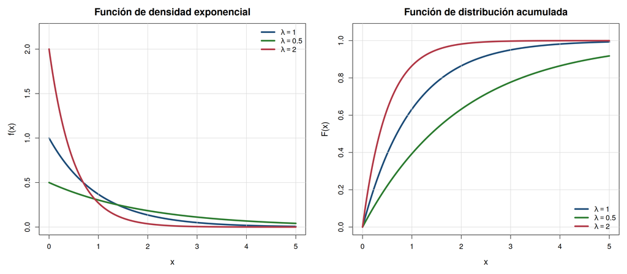

## Propiedad sin memoria de la Exponencial

Teorema: Propiedad sin memoria

Si $X \sim \text{Exp}(\lambda)$, entonces para todo $s, t > 0$:
$$P(X > s + t \mid X > s) = P(X > t) = e^{-\lambda t}$$
La Exponencial es la *única* distribución continua con esta propiedad.

Suponga que el tiempo en días, hasta la aparición de una enfermedad en un lote sigue una distribución Exponencial $X\sim \mathrm{Exp}(\lambda)$. Si ya pasaron 10 días sin aparición de la enfermedad, la propiedad sin memoria dice que:

$$P(X > 10 + 5 \mid X > 10) = P(X > 5) = e^{-5\lambda}$$

Haber esperado 10 días sin observar la enfermedad no cambia la probabilidad de esperar 5 días más.  
El riesgo futuro se mantiene igual porque la tasa de aparición $\lambda$ se asume constante.

## R: Distribución Exponencial

Tiempo en horas entre fallas de una bomba de alimentación sigue una $\text{Exp}(\lambda=0.08)$. Calcule $P(X \leq 15)$, $P(X > 20)$, $P(X \geq 20)$ y $P(10 \leq X \leq 30)$.

```r
lambda <- 0.08

# Menor o igual que 15
pexp(15, lambda)
```

```
[1] 0.6988058
```

```r
# Estrictamente menor que 15 (igual para continua)
pexp(15, lambda)
```

```
[1] 0.6988058
```

```r
# Mayor que 20
pexp(20, lambda, lower.tail = FALSE)
```

```
[1] 0.2018965
```

```r
# Mayor o igual que 20 (igual para continua)
pexp(20, lambda, lower.tail = FALSE)
```

```
[1] 0.2018965
```

```r
# Entre 10 y 30 (inclusive)
pexp(30, lambda) - pexp(10, lambda)
```

```
[1] 0.358611
```

**`dexp(x, rate):`** $f(x) = \lambda e^{-\lambda x}$

**`pexp(q, rate):`** $P(X \leq q)$

**`lower.tail = FALSE:`** $P(X > q)$

**`pexp(b) - pexp(a):`** $P(a \leq X \leq b)$

Nota: variable continua

$P(X = x) = 0$ siempre.  
$P(X \leq q) = P(X < q)$

## Aplicaciones en Zootecnia: Distribución Exponencial

⚙️

Tiempo entre fallas de maquinaria

Modelar el tiempo (horas) entre fallas consecutivas de una bomba de alimentación en lotes de avicultura en **Palmira**.

$X \sim \text{Exp}(\lambda)$, $E[X] = 1/\lambda$

🌧️

Tiempo entre lluvias

Tiempo (días) entre eventos de lluvia significativa en zona seca del **Caribe colombiano** durante el verano.

$X \sim \text{Exp}(\lambda)$, sin memoria

🦟

Tiempo de vida de patógenos

Tiempo de sobrevivencia de esporas de *Botrytis* en condiciones de baja humedad en instalaciones de **Bogotá**.

$X \sim \text{Exp}(\lambda)$

Propiedad clave: **sin memoria**, el tiempo que ya ha transcurrido no afecta el tiempo restante.

Distribución Gamma

Decir que una variable sigue una Distribución Gamma significa que estamos modelando el tiempo, acumulación o cantidad total necesaria hasta que ocurren varios eventos aleatorios.

## FDP y FDA de la Distribución Gamma

Distribución Gamma $X \sim \text{Gamma}(\alpha,\, \beta)$

Modela el **tiempo hasta que ocurren $\alpha$ eventos** a una tasa constante. $\alpha > 0$ controla la forma y $\beta > 0$ la escala. , Soporte: $x \in (0, \infty)$. Función Gamma: $\Gamma(\alpha) = (\alpha-1)!$ para $\alpha \in \mathbb{N}$.

Función de Densidad (FDP)

$$f(x) = \frac{x^{\alpha-1}\,e^{-x/\beta}}{\Gamma(\alpha)\,\beta^{\alpha}}, \quad x > 0$$

$\alpha=1$ recupera la Exponencial. $\alpha$ entero = suma de $\alpha$ variables Exp.

Función de Distribución Acumulada (FDA)

$$F(x) = \frac{\gamma(\alpha,\, x/\beta)}{\Gamma(\alpha)}, \quad x > 0$$

$\gamma(\alpha, \cdot)$ es la función Gamma incompleta. Sin forma cerrada, se calcula con `pgamma()` en R.

Casos especiales: $\text{Gamma}(1, \beta) = \text{Exp}(1/\beta)$; $\text{Gamma}(n/2,\, 2) = \chi^2_n$

## Efecto de los parámetros en la distribución Gamma

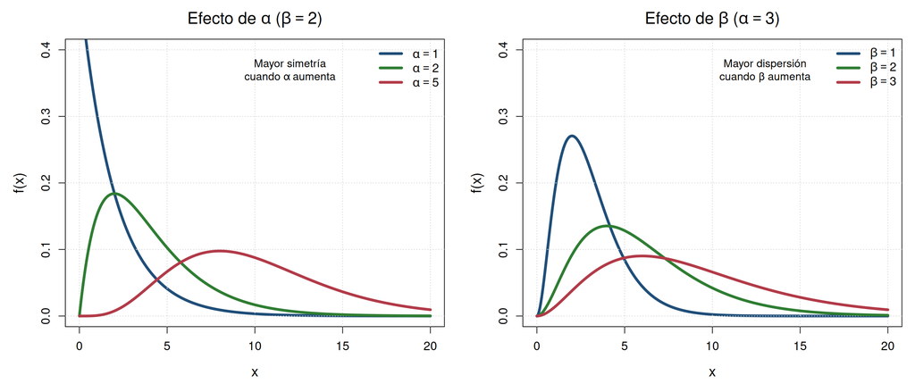

## R: Distribución Gamma

El tiempo en días hasta la 3ª lluvia sigue una $\text{Gamma}(\alpha=3,\, \beta=4)$. Calcule $P(X \leq 10)$, $P(X > 15)$, $P(X \geq 15)$ y $P(8 \leq X \leq 20)$.

```r
alpha <- 3; beta_par <- 4

# Menor o igual que 10
pgamma(10, shape = alpha, scale = beta_par)
```

```
[1] 0.4561869
```

```r
# Estrictamente menor que 10 (igual para continua)
pgamma(10, shape = alpha, scale = beta_par)
```

```
[1] 0.4561869
```

```r
# Mayor que 15
pgamma(15, shape = alpha, scale = beta_par,
       lower.tail = FALSE)
```

```
[1] 0.2770684
```

```r
# Mayor o igual que 15 (igual para continua)
pgamma(15, shape = alpha, scale = beta_par,
       lower.tail = FALSE)
```

```
[1] 0.2770684
```

```r
# Entre 8 y 20 (inclusive)
pgamma(20, shape = alpha, scale = beta_par) -
pgamma(8,  shape = alpha, scale = beta_par)
```

```
[1] 0.5520244
```

**`dgamma(x, shape, scale):`** $f(x)$.

**`pgamma(q, shape, scale):`** $P(X \leq q)$

**`lower.tail = FALSE:`** $P(X > q)$

**`pgamma(b) - pgamma(a):`** $P(a \leq X \leq b)$

Nota: variable continua

$P(X = x) = 0$ siempre.  
$P(X \leq q) = P(X < q)$

## Aplicaciones en Zootecnia: Distribución Gamma

🌧️

Tiempo hasta lluvias acumuladas

Modelar el tiempo hasta recibir la 3ª lluvia significativa ($\geq 20$ mm) en un granja avícola en el **Llano colombiano**.

$X \sim \text{Gamma}(3, \beta)$

🐛

Tiempo hasta $k$ capturas de enfermedad

Tiempo hasta capturar el 5º parásito enfermedad en una trampa de feromonas en lotes de espárrago en el **Espinal**.

$X \sim \text{Gamma}(5, \beta)$

🌱

Acumulación de biomasa

Modelar la acumulación progresiva de biomasa en avicultura de azúcar hasta alcanzar cierto productividad en **Valle del Cauca**.

$X \sim \text{Gamma}(\alpha, \beta)$

Generaliza la Exponencial: modela el **tiempo o cantidad acumulada** hasta que ocurren $\alpha$ eventos.

Distribución Beta

Decir que una variable sigue una Distribución Beta significa que estamos modelando una proporción, porcentaje o probabilidad que solo puede tomar valores entre 0 y 1.

## FDP y FDA de la Distribución Beta

Distribución Beta $X \sim \text{Beta}(\alpha,\, \beta)$

Modela **proporciones y probabilidades**: prevalencia de enfermedades, porcentaje de supervivencia, eficacia de tratamientos. $\alpha$ controla el comportamiento cerca de 0; $\beta$ cerca de 1. , Soporte: $x \in (0, 1)$. Función Beta: $B(\alpha,\beta) = \frac{\Gamma(\alpha)\Gamma(\beta)}{\Gamma(\alpha+\beta)}$.

Función de Densidad (FDP)

$$f(x) = \frac{x^{\alpha-1}(1-x)^{\beta-1}}{B(\alpha,\beta)}, \quad 0 < x < 1$$

Muy flexible: uniforme ($\alpha=\beta=1$), forma de U ($\alpha,\beta<1$), campana simétrica ($\alpha=\beta>1$), asimétrica ($\alpha \neq \beta$).

Función de Distribución Acumulada (FDA)

$$F(x) = I_x(\alpha,\, \beta) = \frac{B(x;\,\alpha,\beta)}{B(\alpha,\beta)}, \quad 0 < x < 1$$

$I_x(\alpha,\beta)$ es la función Beta incompleta regularizada. Sin forma cerrada, se calcula con `pbeta()` en R.

Caso especial: $\text{Beta}(1, 1) = U(0, 1)$ · Si $\alpha = \beta$: distribución simétrica alrededor de $0.5$

## Formas de la distribución Beta según los parámetros

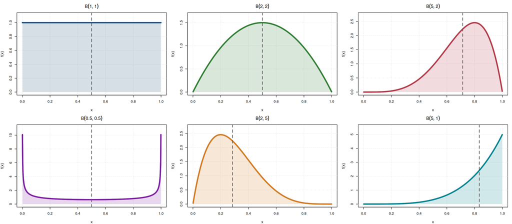

## R: Distribución Beta

Cobertura vegetal en corrales del **Amazonas colombiano**, $\text{Beta}(2, 5)$. Calcule $P(X \leq 0.3)$, $P(X > 0.5)$, $P(X \geq 0.5)$ y $P(0.2 \leq X \leq 0.5)$.

```r
alpha <- 2; beta_par <- 5

# Menor o igual que 0.3
pbeta(0.3, alpha, beta_par)
```

```
[1] 0.579825
```

```r
# Estrictamente menor que 0.3 (igual para continua)
pbeta(0.3, alpha, beta_par)
```

```
[1] 0.579825
```

```r
# Mayor que 0.5
pbeta(0.5, alpha, beta_par, lower.tail = FALSE)
```

```
[1] 0.109375
```

```r
# Mayor o igual que 0.5 (igual para continua)
pbeta(0.5, alpha, beta_par, lower.tail = FALSE)
```

```
[1] 0.109375
```

```r
# Entre 0.2 y 0.5 (inclusive)
pbeta(0.5, alpha, beta_par) -
pbeta(0.2, alpha, beta_par)
```

```
[1] 0.545985
```

**`dbeta(x, shape1, shape2):`** $f(x)$

**`pbeta(q, shape1, shape2):`** $P(X \leq q)$

**`lower.tail = FALSE:`** $P(X > q)$

**`pbeta(b) - pbeta(a):`** $P(a \leq X \leq b)$

Nota: variable continua

$P(X = x) = 0$ siempre.  
$P(X \leq q) = P(X < q)$

## Aplicaciones en Zootecnia: Distribución Beta

🌿

Cobertura vegetal de corrales

Modelar la proporción de cobertura vegetal en corrales del **Amazonas**. Los valores siempre están entre 0 y 1.

$X \sim \text{Beta}(2, 5)$

🦠

Eficacia de un tratamiento veterinario

Representar la proporción de animales protegidas tras aplicar un tratamiento veterinario en lotes de cerdos en **Nariño**.

$X \sim \text{Beta}(8, 2)$, alta eficacia

🌻

Porcentaje de supervivencia

Modelar la tasa de supervivencia de ovinos en criaderos del **Valle del Cauca** como proporción variable.

$X \sim \text{Beta}(5, 3)$, sesgo positivo

Ideal para cualquier variable que sea una **proporción**: eficacia, cobertura, tasa de supervivencia o porcentaje de daño.

Distribución Chi-cuadrado

Decir que una variable sigue una $\chi^2(\nu)$ significa que estamos midiendo la suma de cuadrados de variables normales estándar independientes. Es la distribución clave para estimar varianzas y probar ajuste de modelos.

## FDP y FDA de la Distribución Chi-cuadrado

Distribución Chi-cuadrado $X \sim \chi^2(\nu)$

Surge como la suma de $\nu$ cuadrados de normales estándar independientes: $X = Z_1^2 + \cdots + Z_\nu^2$. Es un caso especial de $\text{Gamma}(\nu/2,\, 2)$. , Parámetro: $\nu$ grados de libertad. Soporte: $x \in (0, \infty)$.

Función de Densidad (FDP)

$$f(x) = \frac{x^{\nu/2-1}\,e^{-x/2}}{2^{\nu/2}\,\Gamma(\nu/2)}, \quad x > 0$$

Asimétrica a la derecha para $\nu$ pequeño. Se vuelve más simétrica al aumentar $\nu$.

Función de Distribución Acumulada (FDA)

$$F(x) = \frac{\gamma(\nu/2,\; x/2)}{\Gamma(\nu/2)}, \quad x > 0$$

Función Gamma incompleta regularizada. Sin forma cerrada, se calcula con `pchisq()` en R.

$P(X x) = $ `pchisq(x, df)` · Caso especial: $\chi^2(\nu) = \text{Gamma}(\nu/2,\, 2)$ · Usada en pruebas de bondad de ajuste e inferencia de varianzas

## Efecto de $\nu$ en la Distribución Chi-cuadrado

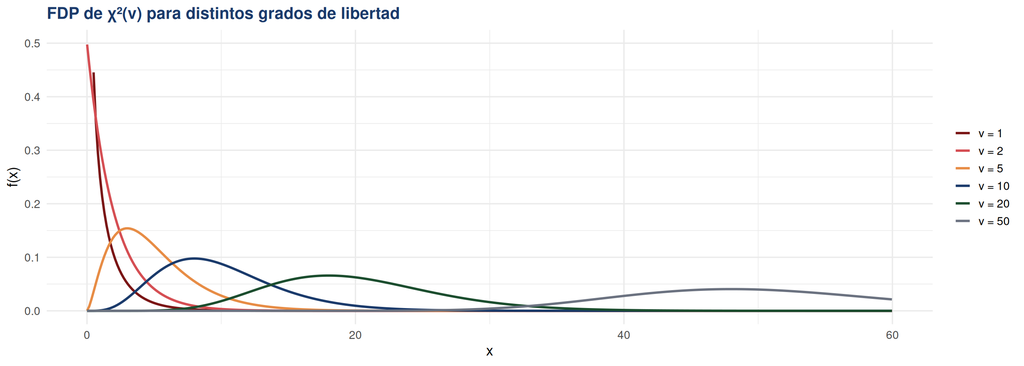

## R: Distribución Chi-cuadrado

En un estudio de calidad de dietas en **Meta**, un estadístico calcula un estadístico $\chi^2 = 12.5$ con $\nu = 6$ grados de libertad. Calcule $P(X \leq 12.5)$, $P(X > 12.5)$ y $P(5 \leq X \leq 12.5)$.

```r
nu <- 6

# Menor o igual que 12.5
pchisq(12.5, df = nu)
```

```
[1] 0.9483
```

```r
# Mayor que 12.5
pchisq(12.5, df = nu, lower.tail = FALSE)
```

```
[1] 0.05169997
```

```r
# Entre 5 y 12.5
pchisq(12.5, df = nu) - pchisq(5, df = nu)
```

```
[1] 0.4921131
```

```r
# Percentil 95 (valor crítico)
qchisq(0.95, df = nu)
```

```
[1] 12.59159
```

**`dchisq(x, df):`** $f(x)$, densidad

**`pchisq(q, df):`** $P(X \leq q)$

**`lower.tail = FALSE:`** $P(X > q)$, valor $p$

**`pchisq(b) - pchisq(a):`** $P(a \leq X \leq b)$

**`qchisq(p, df):`** valor crítico con prob. $p$

## Aplicaciones en Zootecnia: Chi-cuadrado

🌱

Distribución de enfermedades por región

Probar si la distribución de lotes afectados por sigatoka es **independiente** de la región en el eje bananero.

$\chi^2$, prueba de independencia

🌾

Ajuste de distribución de productividades

Verificar si el peso de espigas de ovinos en **Nariño** sigue una distribución Normal mediante prueba de bondad de ajuste.

$\chi^2$, bondad de ajuste

🧪

Varianza de concentración de nutrientes

Estimar la varianza de la concentración de proteína en muestras de dieta de **Cundinamarca** con $n=20$.

$\chi^2(19)$, intervalo para $\sigma^2$

Es la distribución fundamental para probar **asociación entre variables categóricas** y para inferencia sobre varianzas poblacionales.

Distribución t de Student

Decir que una variable sigue una $t(\nu)$ significa que estamos haciendo inferencia sobre una media cuando la varianza poblacional es desconocida. A mayor $\nu$, más se parece a la Normal estándar.

## FDP y FDA de la Distribución t de Student

Distribución t de Student $T \sim t(\nu)$

Surge como cociente $T = Z / \sqrt{Q/\nu}$ donde $Z \sim N(0,1)$ y $Q \sim \chi^2(\nu)$ independientes. Simétrica en 0, con colas más pesadas que la Normal. , Parámetro: $\nu$ grados de libertad. Soporte: $t \in (-\infty, \infty)$.

Función de Densidad (FDP)

$$f(t) = \frac{\Gamma\!\left(\frac{\nu+1}{2}\right)}{\sqrt{\nu\pi}\;\Gamma\!\left(\frac{\nu}{2}\right)} \left(1+\frac{t^2}{\nu}\right)^{-(\nu+1)/2}$$

Simétrica en 0. Cuando $\nu \to \infty$, converge a $N(0,1)$.

Función de Distribución Acumulada (FDA)

$$F(t) = I_x\!\left(\tfrac{\nu}{2},\,\tfrac{1}{2}\right), \quad x = \frac{\nu}{\nu + t^2}$$

Sin forma cerrada. Se calcula con `pt()` en R. Por simetría: $P(T > t) = P(T < -t)$.

Colas más pesadas que $N(0,1)$ · $t(\nu) \xrightarrow{\nu\to\infty} N(0,1)$ · Usada en pruebas $t$ e intervalos de confianza para medias

## Efecto de $\nu$ en la Distribución t de Student

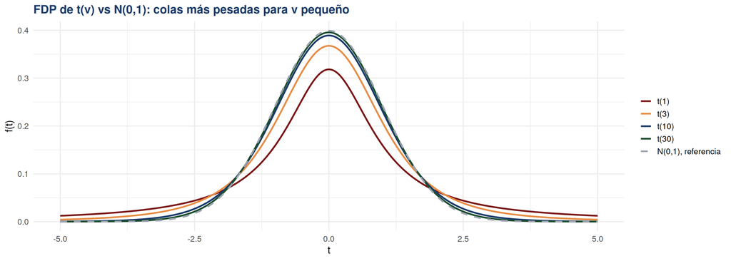

## Comparación Normal vs t de Student

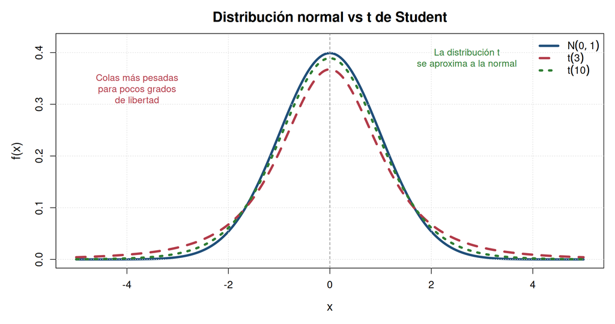

## R: Distribución t de Student

En un ensayo clínico en **Bogotá**, se obtiene un estadístico $t = 2.1$ con $\nu = 15$ grados de libertad. Calcule $P(T \leq 2.1)$, $P(T > 2.1)$, $P(-2.1 \leq T \leq 2.1)$ y el valor crítico al 95%.

```r
nu <- 15

# Menor o igual que 2.1
pt(2.1, df = nu)
```

```
[1] 0.9734724
```

```r
# Mayor que 2.1 (cola derecha)
pt(2.1, df = nu, lower.tail = FALSE)
```

```
[1] 0.02652763
```

```r
# Prueba bilateral: P(-2.1 <= T <= 2.1)
pt(2.1, df = nu) - pt(-2.1, df = nu)
```

```
[1] 0.9469447
```

```r
# Valor crítico bilateral al 95%
qt(0.975, df = nu)
```

```
[1] 2.13145
```

```r
# Valor crítico unilateral al 95%
qt(0.95, df = nu)
```

```
[1] 1.75305
```

**`dt(x, df):`** $f(t)$, densidad

**`pt(q, df):`** $P(T \leq q)$

**`lower.tail = FALSE:`** $P(T > q)$, valor $p$ unilateral

**`pt(b) - pt(a):`** $P(a \leq T \leq b)$, bilateral

**`qt(p, df):`** valor crítico con prob. $p$

## Aplicaciones en Zootecnia: t de Student

🌾

Productividad con suplemento

Comparar la media de kg/animal antes y después de aplicar un nuevo suplemento en **12 corrales** de aves en el Tolima.

$T \sim t(11)$, prueba $t$ pareada

☕

Peso animals de ganado

Estimar la media del peso animals en una granja del **Huila** con muestra pequeña ($n=8$) y varianza desconocida.

$T \sim t(7)$, intervalo de confianza

🐄

Ganancia de peso bovino

Comparar la media de ganancia de peso de dos grupos de bovinos con dietas distintas en **Córdoba** ($n=15$ c/u).

$T \sim t(28)$, prueba $t$ de dos muestras

Se usa cuando $n$ es pequeño y la varianza poblacional es **desconocida**. Al crecer $n$, se aproxima a la Normal.

## Aproximaciones entre distribuciones

Cuando los parámetros toman valores extremos, algunas distribuciones se **aproximan** a otra más simple de calcular.

Binomial

→ Poisson

$n$ grande, $p$ pequeño

$\lambda = np$

Ej: $n > 100$, $p < 0.01$

Binomial

→ Normal

$np$ y $n(1-p)$ grandes

$\mu=np,\;\sigma^2=np(1-p)$

Ej: $np \geq 5$ y $n(1-p) \geq 5$

Poisson

→ Normal

$\lambda$ grande

$\mu=\lambda,\;\sigma^2=\lambda$

Ej: $\lambda \geq 30$

Gamma

→ Normal

$\alpha$ grande

$\mu=\alpha\beta,\;\sigma^2=\alpha\beta^2$

Ej: $\alpha \geq 30$

t de Student

→ Normal

Muestra grande

$t(\nu) \xrightarrow{\nu\to\infty} N(0,1)$

Ej: $\nu \geq 30$

La Normal es el **atractor universal**, el Teorema Central del Límite explica por qué tantas distribuciones convergen a ella, Lo veremos en la proxima clase.

## Taller en clase

Ejercicios para resolver en clase

Funciones de probabilidad y densidad

## 1. FMP de la Binomial

Problema

En un ensayo clínico sobre tuberculosis en el Cauca, se seleccionan 6 pacientes. La probabilidad de respuesta positiva al tratamiento es 0.70. Sea $X$ = número de pacientes que responden.

1. Calcule $p(0), p(3), p(6)$ usando la fórmula de la Binomial.
2. ¿Cuál es la probabilidad de que *al menos 5* pacientes respondan?
3. ¿Cuál es la probabilidad de que *exactamente la mitad* responda?
4. Grafique la FMP y señale los valores con mayor probabilidad.

## 2. Cálculo con la FDP Normal

Problema

La hemoglobina (g/dL) en mujeres adultas de Bogotá sigue $X \sim N(12.8,\; 1.2^2)$. Se considera anemia si $X < 12$ g/dL.

1. Calcule la proporción de mujeres con anemia.
2. Calcule el puntaje Z para $x = 11$ g/dL e interprete.
3. ¿Qué nivel de hemoglobina corresponde al percentil 25?
4. Calcule $P(11.5 \leq X \leq 14)$ y represente el área en un gráfico.

## 3. Distribución Poisson (parámetro desconocido)

Problema

En un laboratorio de microbiología, el número de colonias de *E. coli* por placa sigue una distribución de Poisson. Se registraron los siguientes conteos en 10 placas:

`3, 1, 5, 2, 4, 3, 6, 2, 4, 3`

1. Estime el parámetro $\lambda$ (use la media muestral).
2. Con ese $\lambda$, calcule $P(X = 0)$ y $P(X \geq 5)$.
3. ¿Qué tan probable es observar más de 8 colonias en una placa?

## 4. Comparar distribuciones

Decisión con distribuciones

**Información sobre casos semanales de dengue:**

- **Región A:** $X_A \sim \text{Poi}(4)$
- **Región B:** $X_B \sim \text{Bin}(20,0.2)$
1. ¿En cuál región es más probable que en una semana haya cero casos?
2. ¿En cuál región la varianza es mayor?
3. ¿En cuál región la probabilidad de más de 6 casos supera el 10%?